# Project

Joel Bravo

December 2, 2018

```r
#load the data
bikeData <- read.csv("C:/Users/brmor/OneDrive/Documents/hour.csv", header = TRUE)
```

**When is the daily peak usage?**

```r
#Determine the index for the max count
index <- which.max(bikeData$cnt)
#Determine the time of day for the max count
bikeData[index,]
```

```
##       instant     dteday season yr mnth hr holiday weekday workingday
## 14774   14774 2012-09-12      3  1    9 18       0       3          1
##       weathersit temp  atemp  hum windspeed casual registered cnt
## 14774          1 0.66 0.6212 0.44    0.2537     91        886 977
```

```r
#The hour with the max count is 18 or 6pm. Use sqldf to look at all of the records that have hour 18
sixpm <- sqldf("SELECT * FROM bikeData WHERE hr = 18")
head(sixpm)
```

```
##   instant     dteday season yr mnth hr holiday weekday workingday
## 1      19 2011-01-01      1  0    1 18       0       6          0
## 2      42 2011-01-02      1  0    1 18       0       0          0
## 3      64 2011-01-03      1  0    1 18       0       1          1
## 4      87 2011-01-04      1  0    1 18       0       2          1
## 5     110 2011-01-05      1  0    1 18       0       3          1
## 6     133 2011-01-06      1  0    1 18       0       4          1
##   weathersit temp  atemp  hum windspeed casual registered cnt
## 1          3 0.42 0.4242 0.88    0.2537      9         26  35
## 2          2 0.36 0.3333 0.46    0.3284     10         43  53
## 3          1 0.24 0.2576 0.32    0.1045      9        148 157
## 4          1 0.26 0.2576 0.48    0.1940      3        179 182
## 5          1 0.24 0.2424 0.38    0.1343      3        166 169
## 6          1 0.22 0.2273 0.51    0.1343      5        158 163
```

```r
#Compare the sum of the counts for each hour
hours <- sqldf("SELECT hr, SUM(cnt) AS SUM_OF_COUNT FROM bikeData GROUP BY hr")
hours
```

```
##    hr SUM_OF_COUNT
## 1   0        39130
## 2   1        24164
## 3   2        16352
## 4   3         8174
## 5   4         4428
## 6   5        14261
## 7   6        55132
## 8   7       154171
## 9   8       261001
## 10  9       159438
## 11 10       126257
## 12 11       151320
## 13 12       184414
## 14 13       184919
## 15 14       175652
## 16 15       183149
## 17 16       227748
## 18 17       336860
## 19 18       309772
## 20 19       226789
## 21 20       164550
## 22 21       125445
## 23 22        95612
## 24 23        63941
```

```r
#Determine the hour with the max count
maxHours <- sqldf("SELECT hr, max(SUM_OF_COUNT) AS max FROM hours")
maxHours
```

```
##   hr    max
## 1 17 336860
```

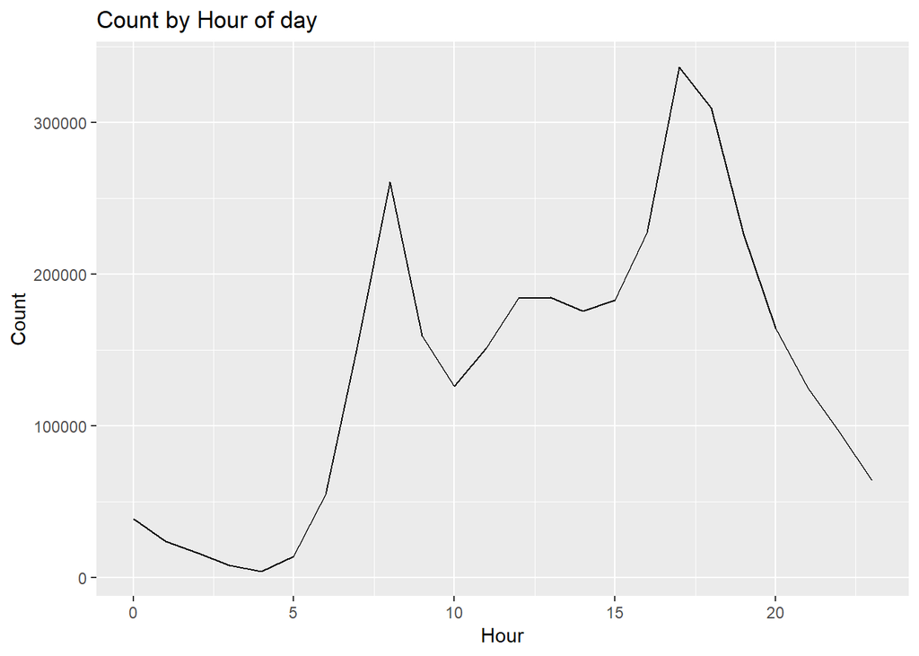

```r
options(scipen = 5)
#Plot usage by day to observe trends
daily <- ggplot(hours, aes(x=hr, y = SUM_OF_COUNT)) + geom_line() + ylab("Count") + xlab("Hour") + ggtitle("Count by Hour of day")
daily
```

Daily peak usage appears to be at 17:00 or 5 pm.

**What is the pattern of usage weekly/monthly/seasonally?**

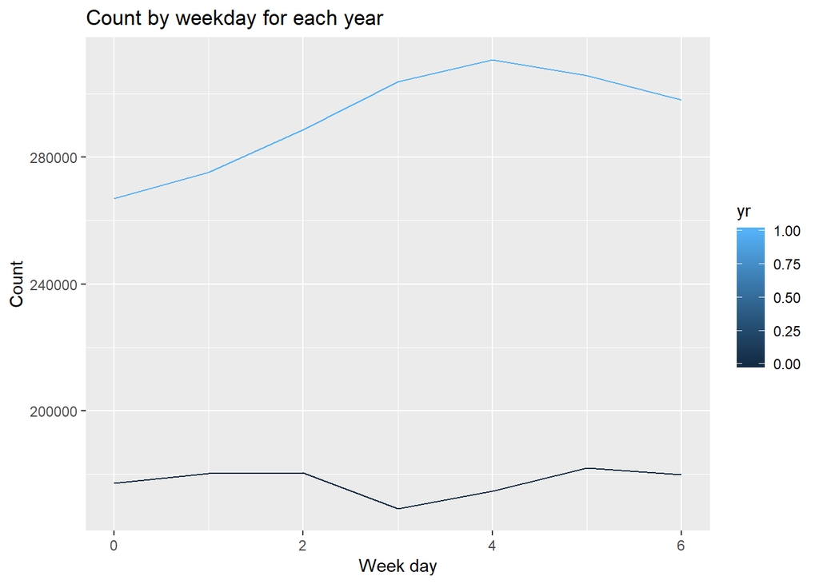

```r
#Start with weekly. Create a line chart for count by week
week <- sqldf("SELECT SUM(cnt) AS SUM_OF_COUNT, weekday, yr FROM bikeData GROUP BY yr, weekday")
week.line <- ggplot(week, aes(x = weekday, y = SUM_OF_COUNT, group = yr, color = yr)) + geom_line() + ylab("Count") + xlab("Week day") + ggtitle("Count by weekday for each year")
week.line
```

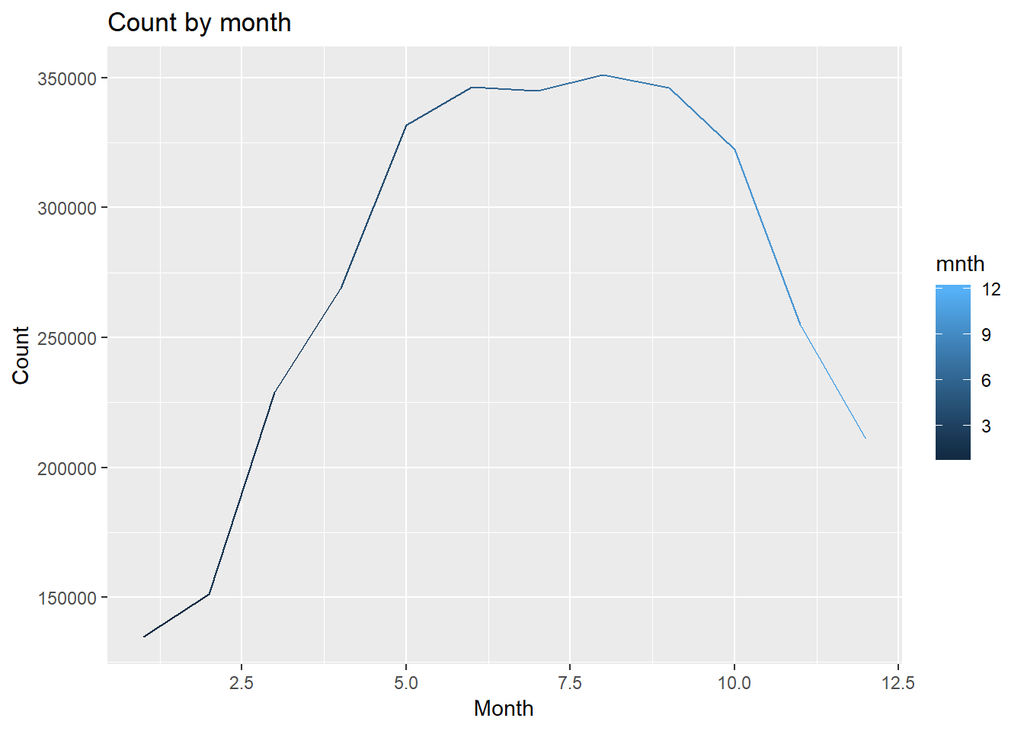

```r
#Create a line chart for count by month.
months <- sqldf("SELECT SUM(cnt) AS SUM_OF_COUNT, mnth FROM bikeData GROUP BY mnth")
month.line <- ggplot(months, aes(x = mnth, y = SUM_OF_COUNT, color = mnth)) + geom_line() + expand_limits(x = c(1,12)) + ylab("Count") + xlab("Month") + ggtitle("Count by month")
month.line
```

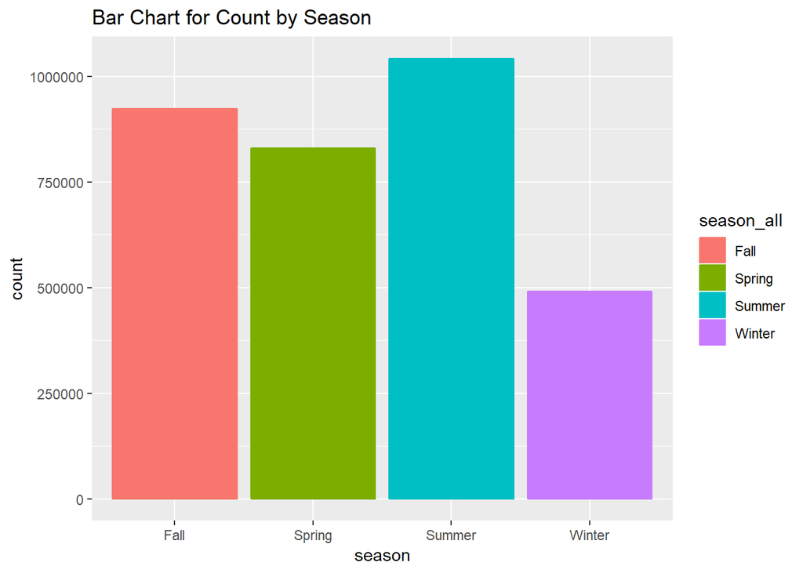

```r
#Create a bar chart for count by season
#first find all season data
seasons <- sqldf("SELECT season, SUM(cnt) AS SUM_OF_COUNT FROM bikeData GROUP BY season")
winter <- seasons[c(1:2,12),]
spring <- seasons[3:5,]
summer <- seasons[6:8,]
fall <- seasons[9:11,]

#create vectors to replicate the seasons by the count
winterRep <- replicate(491321, "Winter")
springRep <- replicate(829700, "Spring")
summerRep <- replicate(1042484, "Summer")
fallRep <- replicate(923174,"Fall")

#create a vector containing all seasons, the turn it into a data frame
season_all <- c(winterRep, springRep, summerRep, fallRep)
season_all <- as.data.frame(season_all)

#plot the season data as a bar chart
season.plot <- ggplot(data = season_all) + geom_bar(data = season_all, aes(x=season_all, color = season_all, fill = season_all)) + ggtitle("Bar Chart for Count by Season") + xlab("season")
season.plot
```

Not surprisingly, the summer has more users than any other season.

**What is the pattern of usage based on weather conditions?**

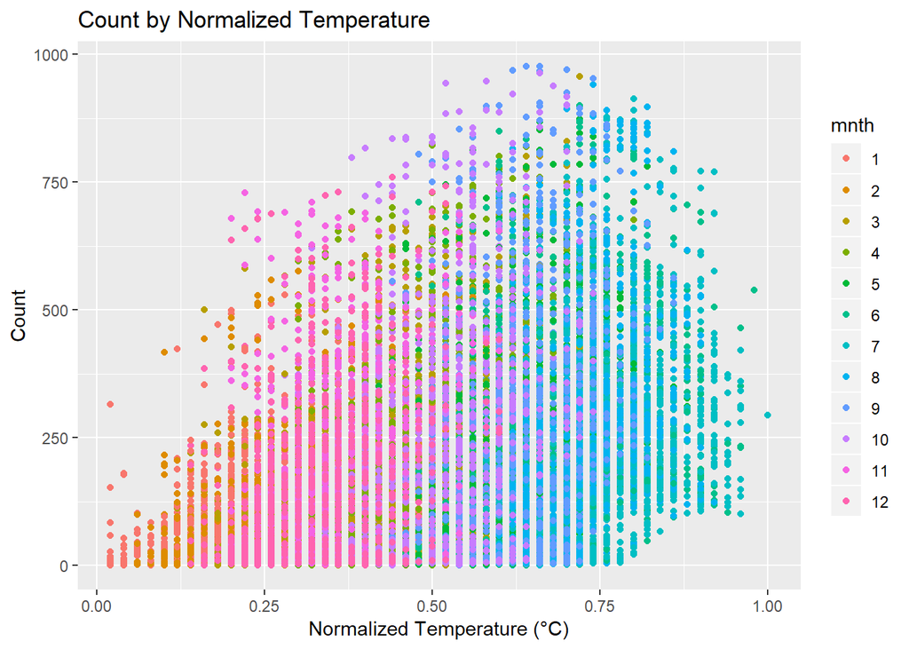

```r
#Create scatter charts for count based on each weather condition.

#Start with temp
bikeData$mnth <- as.factor(bikeData$mnth)
temp <- ggplot(bikeData, aes(x = temp, y = cnt, color = mnth)) + geom_point() + ggtitle("Count by Normalized Temperature") + ylab("Count") + xlab("Normalized Temperature (°C)")
temp
```

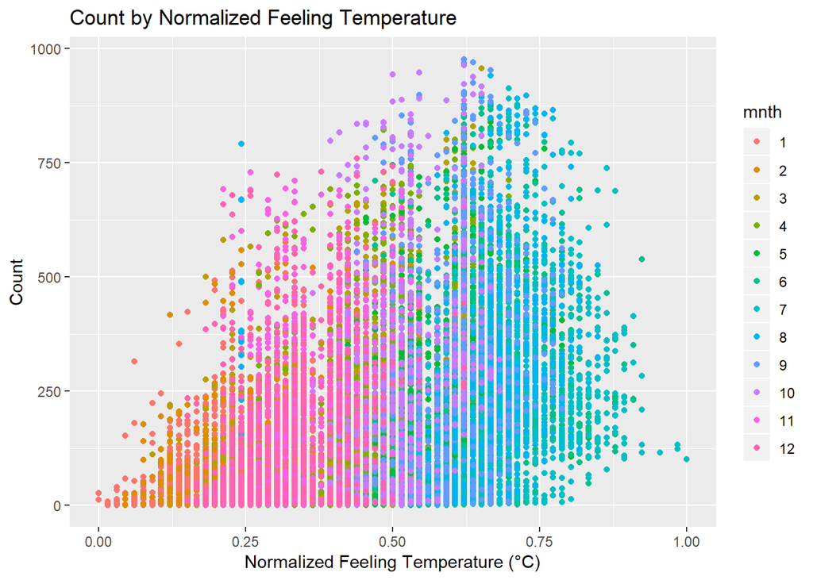

```r
#Now create plot for atemp
atemp <- ggplot(bikeData, aes(x = atemp, y = cnt, color = mnth)) + geom_point() + ggtitle("Count by Normalized Feeling Temperature") + ylab("Count") + xlab("Normalized Feeling Temperature (°C)")
atemp
```

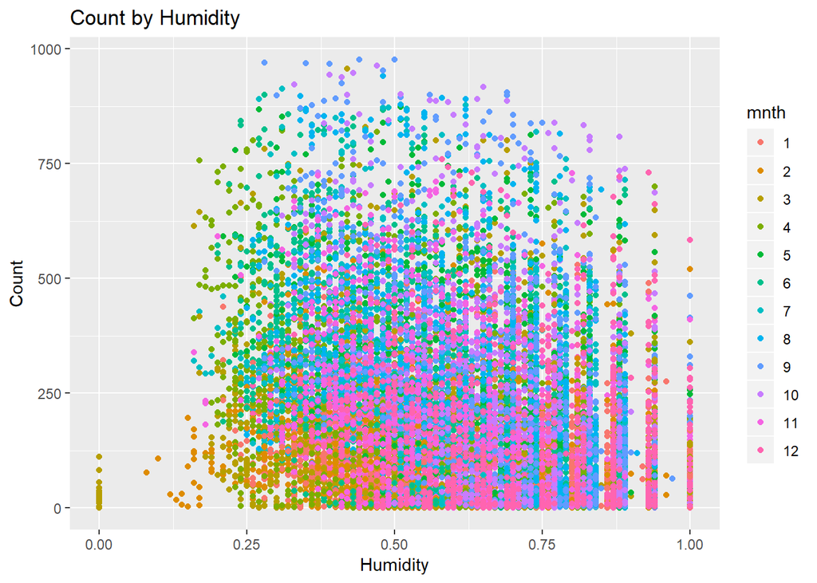

```r
#Plot for humidity
hum <- ggplot(bikeData, aes(x = hum, y = cnt, color = mnth)) + geom_point() + ggtitle("Count by Humidity") + ylab("Count") + xlab("Humidity")
hum
```

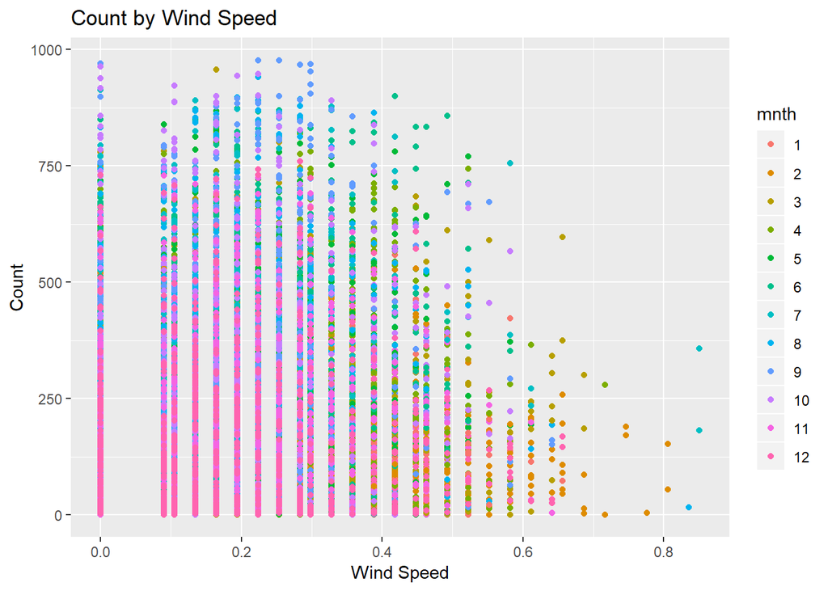

```r
#Plot for wind speed
windspeed <- ggplot(bikeData, aes(x = windspeed, y = cnt, color = mnth)) + geom_point() + ggtitle("Count by Wind Speed") + ylab("Count") + xlab("Wind Speed")
windspeed
```

**What is the pattern of usage based on user’s membership type? (e.g. Who impacts bigger impact on the usage? Commuters or tourists?)**

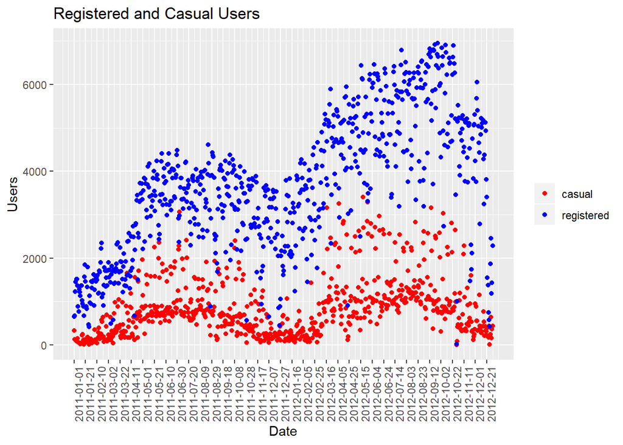

```r
#Get the count of casual and registered users by date
users <- sqldf("SELECT SUM(casual) AS casual, SUM(registered) AS registered, dteday FROM bikeData GROUP by dteday")
users$dteday <- as.Date(users$dteday)
#Create a scatter plot with both registered and casual users
users.plot <- ggplot(users, aes(x = dteday)) + geom_point(data = users, aes(y = casual, color = "casual")) + geom_point(data = users, aes(y = registered, color = "registered")) + scale_color_manual("", breaks = c("casual","registered"), values = c("red","blue")) + ggtitle("Registered and Casual Users") + ylab("Users") + xlab("Date") + theme(axis.text.x = element_text(angle = 90, hjust = 1)) + scale_x_date(breaks = users$dteday[seq(1,length(users$dteday),by = 20)])
users.plot
```

Registered users appear to use the bikes more frequently than casual users.

**Which factors have strong correlations to usage? (e.g. Between weather and day of the week, does one variable correlate stronger?)**

```r
bikeData2 <- read.table("C:/Users/brmor/OneDrive/Documents/hour.csv", header=TRUE, sep=",", na.strings="NA", dec=".",
  strip.white=TRUE)
cor(bikeData2[,c("atemp","cnt","hum","temp","windspeed")], use="complete")
```

```
##                 atemp         cnt         hum        temp   windspeed
## atemp      1.00000000  0.40092930 -0.05191770  0.98767214 -0.06233604
## cnt        0.40092930  1.00000000 -0.32291074  0.40477228  0.09323378
## hum       -0.05191770 -0.32291074  1.00000000 -0.06988139 -0.29010490
## temp       0.98767214  0.40477228 -0.06988139  1.00000000 -0.02312526
## windspeed -0.06233604  0.09323378 -0.29010490 -0.02312526  1.00000000
```

It appears that temperature has the greatest correlation with count.

# Machine Learning

```r
#change the 1s and 0s to yes and no
no <- which(bikeData$workingday == 0)
yes <- which(bikeData$workingday == 1)

bikeData$workingday[no] <- "no"
bikeData$workingday[yes] <- "yes"
#remove the dates from the data so the model can't "cheat"
bikeDatasvm <- bikeData[,9:17]

#determine the number of rows and the corresponding cutpoint
nrows <- nrow(bikeDatasvm)
cutPoint <- floor(nrows/3*2)
#grab random indices so we don't take just the first 2/3
rand <- sample(1:nrows)
#create traning and test data set
bike.train <- bikeDatasvm[rand[1:cutPoint],]
bike.test <- bikeDatasvm[rand[(cutPoint+1):nrows],]
#create our model
model <- ksvm(workingday ~ ., data = bike.train)

#predict yes and no in test data set
pred <- predict(model, bike.test)
results <- table(pred, bike.test$workingday)
totalCorrect <- results[1,1] + results[2,2]
totalInTest <- nrow(bike.test)
#look at % correct and the results
totalCorrect/totalInTest
```

```
## [1] 0.7842223
```

```r
results
```

```
##
## pred    no  yes
##   no   677  116
##   yes 1134 3866
```

# Future Questions

**What predictive analysis can be achieved on future usage?**

**Based on historical data, what else can be automated?**

**How has trends/patterns been affected with introduction of competition, such as dockless scooter sharing?**

**What other external events/variables can have significant impact?**